# Table of Contents

```python
        X_transformed = pd.merge(X_transformed, hourly30_agg,
                                 how="left",
                                 left_on=['half_hour_step'],
                                 right_on=['half_hour_step'],
                                 sort=False
                                )
        X_transformed['half_hourly_diff'] = X_transformed['half_hourly_max'] - X_transformed['half_hourly_min']

        # PCA of Weather Features
        PCA_features = ['visibility', 'temperature', 'humidity', 'humidex', 'windchill', 'wind', 'pressure']
        PCA_data = X_transformed[PCA_features]

        pca = PCA(n_components=3)
        pca3_feature = pca.fit_transform(PCA_data)

        X_transformed['WeatherPCA1'] = pca3_feature[:,0]
        X_transformed['WeatherPCA2'] = pca3_feature[:,1]
        X_transformed['WeatherPCA3'] = pca3_feature[:,2]

        # Windows with margin
        def window_diff(series, start_pos, size, margin):
            #begin = time()
            starting_avg = np.mean(series[start_pos:start_pos+margin])
            ending_avg = np.mean(series[start_pos+size-margin:start_pos+size])
            #end = time()
            #print("CalcDiff Time: %.5f s" %(end-begin))
            return ending_avg - starting_avg

        def window_state(series, start_pos, size, margin, threshold):
            diff = window_diff(series, start_pos, size, margin)
            if diff > threshold:
                return 1
            elif diff < -threshold:
                return -1
            else:
                return 0

        def window_stateV2(series, start_pos, size, margin, lower, upper):
            diff = window_diff(series, start_pos, size, margin)
            if diff > lower and diff < upper:
                return 1
            elif diff > -upper and diff < -lower:
                return -1
            else:
                return 0

        def window_update(series, size, margin, threshold):
            #begin1 = time()
            states = pd.Series(len(series)*[0])
            len_series = len(series)
            for i in range(len_series-size):
                #if i % 10000 == 0:
                    #print(i)
                #begin = time()
                states[i] = window_state(series, i, size, margin, threshold)
                #end = time()
                #print("Update Time: %.5f s" %(end-begin))
            states[len_series-size:] = window_state(series, len_series-size, size, margin, threshold)
            #end1 = time()
            #print("Total Time: %.5f s" %(end1-begin1))
            return states

        def window_updateV2(series, size, margin, lower, upper):
            #begin1 = time()
            states = pd.Series(len(series)*[0])
            len_series = len(series)
            for i in range(len_series-size):
                #if i % 10000 == 0:
                    #print(i)
                #begin = time()
                states[i] = window_stateV2(series, i, size, margin, lower, upper)
                #end = time()
                #print("Update Time: %.5f s" %(end-begin))
            states[len_series-size:] = window_stateV2(series, len_series-size, size, margin, lower, upper)
            #end1 = time()
            #print("Total Time: %.5f s" %(end1-begin1))
            return states

        #######
        def OnOff_update(window_series, size):
            begin1 = time()
            len_series = len(window_series)
            states = pd.Series(len_series*[0])
            i = 0
            while i <= len_series - size:
                #if i % 20000 == 0:
                    #print(i)
                begin = time()
                current_state = window_series[i]
                next_state = window_series[i+1]
                if current_state == 1 and next_state == 0:
                    states[i:i+size] = 1
                    i = i + size
                else:
                    i = i + 1
                end = time()
                #print("Update Time: %.5f s" %(end-begin))
            states[i:] = window_series[i]
            end1 = time()
            #print("Total Time: %.5f s" %(end1-begin1))
            return states

        # Generate window margin
        X_transformed['is_kettle_2500'] = window_update(X_transformed['consumption'], 3, 1, 2500)
        X_transformed['is_kettle_2700'] = window_update(X_transformed['consumption'], 3, 1, 2700)
        X_transformed['is_kettle_2700_5'] = window_update(X_transformed['consumption'], 5, 1, 2700)
        X_transformed['is_kettle_new1'] = window_updateV2(X_transformed['consumption'], 3, 1, 2600, 3000)
        X_transformed['is_washing_1800_5'] = window_update(X_transformed['consumption'], 100, 5, 1800)
        X_transformed['is_washing_2000_10'] = window_update(X_transformed['consumption'], 100, 10, 2000)
        X_transformed['is_washing_2000_5'] = window_update(X_transformed['consumption'], 100, 5, 2000)
        X_transformed['is_washing_new1'] = window_updateV2(X_transformed['consumption'], 100, 5, 1800, 2300)
        X_transformed['is_freezer_new1'] = window_updateV2(X_transformed['consumption'], 25, 3, 50, 200)

        # Generate ON-OFF status prediction
        X_transformed['kettle_current1'] = OnOff_update(X_transformed['is_kettle_2500'], 3)
        X_transformed['kettle_current2'] = OnOff_update(X_transformed['is_kettle_2700'], 3)
        X_transformed['kettle_current3'] = OnOff_update(X_transformed['is_kettle_2700_5'], 5)
        X_transformed['kettle_current_new1'] = OnOff_update(X_transformed['is_kettle_new1'], 3)
        X_transformed['washing_current1'] = OnOff_update(X_transformed['is_washing_1800_5'], 100)
        X_transformed['washing_current2'] = OnOff_update(X_transformed['is_washing_2000_10'], 100)
        X_transformed['washing_current3'] = OnOff_update(X_transformed['is_washing_2000_5'], 100)
        X_transformed['washing_current_new1'] = OnOff_update(X_transformed['is_washing_new1'], 100)
        X_transformed['freezer_current_new1'] = OnOff_update(X_transformed['is_freezer_new1'], 25)
```

```python
        # Consumption Shifting (last 5 min and next 5 min)
        X_transformed['consumption_last1min'] = X_transformed['consumption'].shift(1)
        X_transformed['consumption_last2min'] = X_transformed['consumption'].shift(2)
        X_transformed['consumption_last3min'] = X_transformed['consumption'].shift(3)
        X_transformed['consumption_last4min'] = X_transformed['consumption'].shift(4)
        X_transformed['consumption_last5min'] = X_transformed['consumption'].shift(5)

        X_transformed['consumption_next1min'] = X_transformed['consumption'].shift(-1)
        X_transformed['consumption_next2min'] = X_transformed['consumption'].shift(-2)
        X_transformed['consumption_next3min'] = X_transformed['consumption'].shift(-3)
        X_transformed['consumption_next4min'] = X_transformed['consumption'].shift(-4)
        X_transformed['consumption_next5min'] = X_transformed['consumption'].shift(-5)

        ## Moving average
        X_transformed['last_3min_avg'] = (X_transformed['consumption_last1min'] + X_transformed['consumption_last2min'] + X_transformed['consumption_last3min']) / 3
        X_transformed['last_5min_avg'] = (X_transformed['consumption_last1min'] + X_transformed['consumption_last2min'] + X_transformed['consumption_last3min'] + X_transformed['consumption_last4min'] + X_transformed['consumption_last5min']) / 5

        X_transformed['next_3min_avg'] = (X_transformed['consumption_next1min'] + X_transformed['consumption_next2min'] + X_transformed['consumption_next3min']) / 3
        X_transformed['next_5min_avg'] = (X_transformed['consumption_next1min'] + X_transformed['consumption_next2min'] + X_transformed['consumption_next3min'] + X_transformed['consumption_next4min'] + X_transformed['consumption_next5min']) / 5

        # 5 min aggregations
        X_transformed['consumption_last5min_std'] = np.nan
        X_transformed['consumption_last5min_min'] = np.nan
        X_transformed['consumption_last5min_max'] = np.nan
        X_transformed['consumption_last5min_diff'] = np.nan

        X_transformed['consumption_next5min_std'] = np.nan
        X_transformed['consumption_next5min_min'] = np.nan
        X_transformed['consumption_next5min_max'] = np.nan
        X_transformed['consumption_next5min_diff'] = np.nan

        for i in range(len(X_transformed)):
            list_last5min = [X_transformed.consumption_last1min[i], X_transformed.consumption_last2min[i],
                             X_transformed.consumption_last3min[i], X_transformed.consumption_last4min[i],
                             X_transformed.consumption_last5min[i]]

            list_next5min = [X_transformed.consumption_next1min[i],X_transformed.consumption_next2min[i],
                             X_transformed.consumption_next3min[i],X_transformed.consumption_next4min[i],
                             X_transformed.consumption_next5min[i]]

            X_transformed.consumption_last5min_std[i] = np.std(list_last5min)
            X_transformed.consumption_last5min_min[i] = np.min(list_last5min)
            X_transformed.consumption_last5min_max[i] = np.max(list_last5min)
            X_transformed.consumption_last5min_diff[i] = X_transformed.consumption_last5min_max[i] - X_transformed.consumption_last5min_min[i]

            X_transformed.consumption_next5min_std[i] = np.std(list_next5min)
            X_transformed.consumption_next5min_min[i] = np.min(list_next5min)
            X_transformed.consumption_next5min_max[i] = np.max(list_next5min)
            X_transformed.consumption_next5min_diff[i] = X_transformed.consumption_next5min_max[i] - X_transformed.consumption_next5min_min[i]


        if leave_null == False:
            X_transformed = X_transformed.fillna(0)

        return X_transformed

    def transform_cols(self, X_df):
        return self.X_transformed.columns

    def getDF(self):
        return self.X_transformed
```

```python
### Transform X_train
fe = FeatureExtractor()
X_train_V2 = fe.transform(X_train, leave_null=False)

### Transform X_test
X_test_V2 = fe.transform(X_test, leave_null=False)
```

```python
# NA values imputation for y_train
y_train_V2 = y_train
y_train_V2['kettle'] = y_train_V2['kettle'].fillna(0)
y_train_V2 = y_train_V2.interpolate(method='nearest', limit_direction='forward', limit=5)
y_train_V2 = y_train_V2.fillna(0)
```

```python
# Save transformed data to file for future use
X_train_V2.to_csv("X_train_trans2.csv", index=False)
X_test_V2.to_csv("X_test_trans2.csv", index=False)
y_train_V2.to_csv("y_train_trans2.csv", index=False)
```

```python
# Load preprocessed data
X_train = pd.read_csv("X_train_trans2.csv")
X_test  = pd.read_csv("X_test_trans2.csv")
y_train = pd.read_csv("y_train_trans2.csv")
```

### Data Integration

```python
train = pd.merge(X_train, y_train,
                 how="left",
                 left_on=['time_step'],
                 right_on=['time_step'],
                 sort=False
                )
```

### Data visualization & exploration

Below shows a plot of the consumptions of the entire household and of the 4 appliances in a given time period.

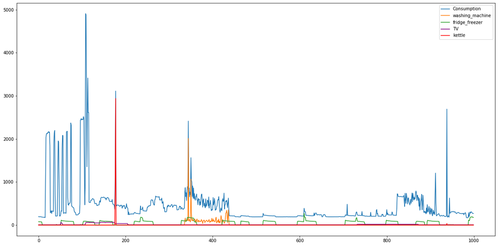

```python
fig = plt.figure(figsize=(20,10))

size = 1000
start = 2400

plot_sample = train.iloc[start:start+size,:]
plt.plot(np.arange(0,size,1), plot_sample['consumption'], label='Consumption')
plt.plot(np.arange(0,size,1), plot_sample['washing_machine'], label='washing_machine')
plt.plot(np.arange(0,size,1), plot_sample['fridge_freezer'], label='fridge_freezer')
plt.plot(np.arange(0,size,1), plot_sample['TV'], label='TV', color="purple")
plt.plot(np.arange(0,size,1), plot_sample['kettle'], label='kettle', color="red")

plt.legend()

plt.show()
```

Below shows the histograms of the electrivity consumption of each appliance.

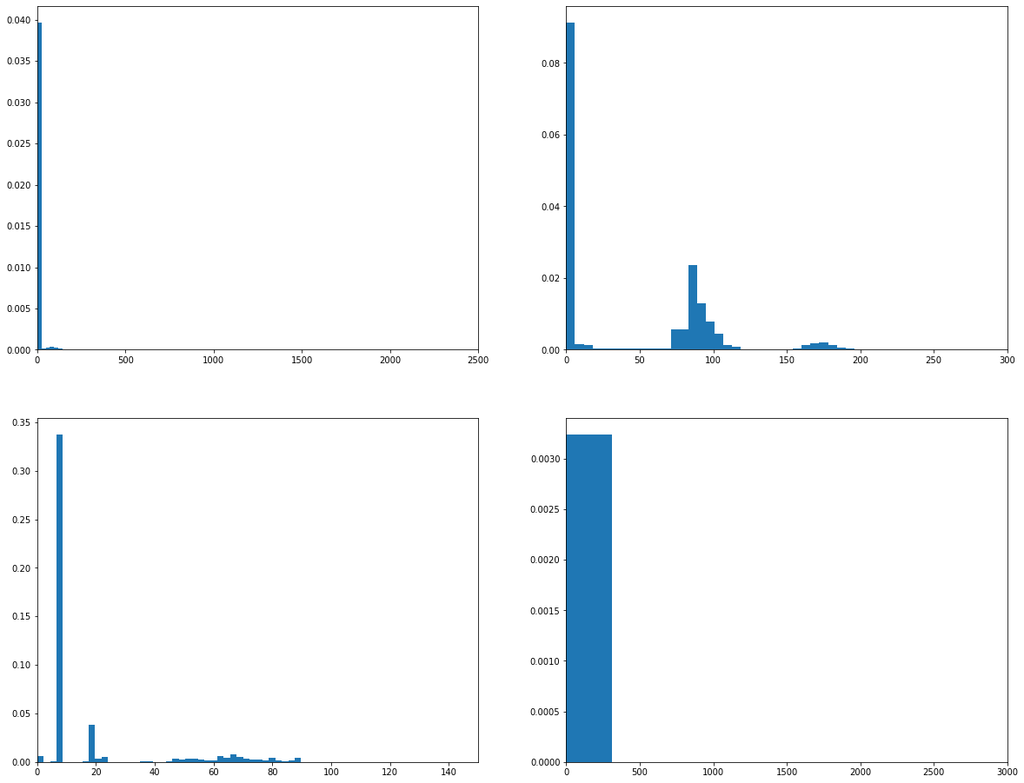

```python
plt.figure(1,figsize = (20,16))

size = 100000
plot_sample = train.iloc[:size,:]

plt.subplot(221)
plt.hist(plot_sample.washing_machine, bins=100, density=True)
plt.xlim(0,2500)

plt.subplot(222)
plt.hist(plot_sample.fridge_freezer, bins=50, density=True)
plt.xlim(0,300)

plt.subplot(223)
plt.hist(plot_sample.TV, bins=50, density=True)
plt.xlim(0,150)

plt.subplot(224)
plt.hist(plot_sample.kettle, bins=10, density=True)
plt.xlim(0,3000)

plt.show()
```

Below we group the consumptions in smaller ranges and count the frequency within each smaller range for each appliance.

```python
y_train_ = train[['washing_machine', 'fridge_freezer', 'TV', 'kettle', 'time_step']]

y_train_['w_m'] = pd.cut(y_train_.washing_machine, [-1, 50, 100, 500, 1000, 1500, 2000, 2500, 3000])
y_train_['f_f'] = pd.cut(y_train_.fridge_freezer, [-1, 50, 150, 200, 250, 300])
y_train_['_tv'] = pd.cut(y_train_.TV, [-1, 10, 20, 30, 40, 50, 60, 70, 80, 90, 100, 120, 140])
y_train_['_kettle'] = pd.cut(y_train_.kettle, [-1, 100, 500, 1000, 1500, 2000, 2500, 3000])
```

```python
y_train_.groupby('w_m').count()[['time_step']]
```

| w_m | time_step |
| --- | --- |
| (-1, 50] | 403493 |
| (50, 100] | 7812 |
| (100, 500] | 5828 |
| (500, 1000] | 152 |
| (1000, 1500] | 127 |
| (1500, 2000] | 65 |
| (2000, 2500] | 122 |
| (2500, 3000] | 0 |

```python
y_train_.groupby('f_f').count()[['time_step']]
```

| f_f | time_step |
| --- | --- |
| (-1, 50] | 210976 |
| (50, 150] | 180255 |
| (150, 200] | 26122 |
| (200, 250] | 215 |
| (250, 300] | 22 |

```python
y_train_.groupby('_tv').count()[['time_step']]
```

| _tv | time_step |
| --- | --- |
| (-1, 10] | 323182 |
| (10, 20] | 36402 |
| (20, 30] | 10772 |
| (30, 40] | 872 |
| (40, 50] | 9692 |
| (50, 60] | 12561 |
| (60, 70] | 15284 |
| (70, 80] | 5722 |
| (80, 90] | 2987 |
| (90, 100] | 56 |
| (100, 120] | 69 |
| (120, 140] | 0 |

```python
y_train_.groupby('_kettle').count()[['time_step']]
```

| _kettle | time_step |
| --- | --- |
| (-1, 100] | 416397 |
| (100, 500] | 183 |
| (500, 1000] | 256 |
| (1000, 1500] | 182 |
| (1500, 2000] | 103 |
| (2000, 2500] | 109 |
| (2500, 3000] | 337 |

### Define basic feature subsets

```python
X_vars_full = ['consumption', 'visibility', 'temperature', 'humidity',
       'humidex', 'windchill', 'wind', 'pressure', 'hour', 'minute', 'month',
       'dayofweek', 'isweekend', 'day_0', 'day_1', 'day_2', 'day_3', 'day_4',
       'day_5', 'day_6', 'hour_0', 'hour_1', 'hour_2', 'hour_3', 'hour_4',
       'hour_5', 'hour_6', 'hour_7', 'hour_8', 'hour_9', 'hour_10', 'hour_11',
       'hour_12', 'hour_13', 'hour_14', 'hour_15', 'hour_16', 'hour_17',
       'hour_18', 'hour_19', 'hour_20', 'hour_21', 'hour_22', 'hour_23',
       'hour_sin', 'hour_cos', 'minute_sin', 'minute_cos', 'time', 'time_sin',
       'time_cos', 'hourly_avg', 'hourly_max', 'hourly_min',
       'hourly_std', 'hourly_diff', 'half_hourly_avg',
       'half_hourly_max', 'half_hourly_min', 'half_hourly_std',
       'half_hourly_diff', 'WeatherPCA1', 'WeatherPCA2', 'WeatherPCA3',
       'is_kettle_2500', 'is_kettle_2700', 'is_kettle_2700_5',
       'is_washing_1800_5', 'is_washing_2000_10', 'is_washing_2000_5',
       'kettle_current1', 'kettle_current2', 'kettle_current3',
       'washing_current1', 'washing_current2', 'washing_current3',
       'consumption_last1min', 'consumption_last2min', 'consumption_last3min',
       'consumption_last4min', 'consumption_last5min', 'is_washing_new1',
       'washing_current_new1', 'is_freezer_new1', 'freezer_current_new1',
       'is_kettle_new1', 'kettle_current_new1', 'last_5min_avg',
       'last_3min_avg']
Y_vars_full = ['washing_machine', 'fridge_freezer', 'TV', 'kettle']
```

```python
X_vars_base = ['consumption']
X_vars_3mins = ['consumption_last1min', 'consumption_last2min', 'consumption_last3min']
X_vars_5mins = ['consumption_last1min', 'consumption_last2min', 'consumption_last3min',
               'consumption_last4min', 'consumption_last5min']
X_vars_day = ['isweekend', 'day_0', 'day_1',
       'day_2', 'day_3', 'day_4', 'day_5', 'day_6']
X_vars_hour1 = ['hour_0', 'hour_1',
       'hour_2', 'hour_3', 'hour_4', 'hour_5', 'hour_6', 'hour_7', 'hour_8',
       'hour_9', 'hour_10', 'hour_11', 'hour_12', 'hour_13', 'hour_14',
       'hour_15', 'hour_16', 'hour_17', 'hour_18', 'hour_19', 'hour_20',
       'hour_21', 'hour_22', 'hour_23']
X_vars_hour2 = ['hour_sin', 'hour_cos']
X_vars_minute = ['minute_sin', 'minute_cos']
X_vars_time = ['time_sin', 'time_cos']
X_vars_hourly = ['hourly_avg', 'hourly_std', 'hourly_max', 'hourly_min']
X_vars_half_hourly = ['half_hourly_avg', 'half_hourly_std', 'half_hourly_max', 'half_hourly_min']
X_vars_weather1 = ['visibility', 'temperature', 'humidity',
                   'humidex', 'windchill', 'wind', 'pressure']
X_vars_weather2 = ['WeatherPCA1', 'WeatherPCA2', 'WeatherPCA3']
X_vars_window1 = ['is_kettle_2500', 'is_washing_1800_5', 'kettle_current1', 'washing_current1']
X_vars_window2 = ['is_kettle_2700', 'is_washing_2000_10', 'kettle_current2', 'washing_current2']
X_vars_window3 = ['is_kettle_2700_5', 'is_washing_2000_5', 'kettle_current3', 'washing_current3']
```

## Linear model

`sklearn.LinearRegression()`

```python
X_linear_set = X_vars_base + X_vars_day + X_vars_time + X_vars_half_hourly
```

```python
X_linear = train[['time_step'] + X_linear_set]
y_linear = train[Y_vars_full]
```

```python
x_train, x_valid, y_train, y_valid = train_test_split(X_linear, y_linear, test_size=0.1)
print('Train size: {train}, Validation size: {test}'.format(train=x_train.shape[0], test=x_valid.shape[0]))
```

```
Train size: 375839, Validation size: 41760
```

```python
# May lead to very bad results
# scaler = StandardScaler()
# x_scaled = scaler.fit_transform(x_train[x_train.columns[1:]])
# y_scaled = scaler.fit_transform(y_train)
```

```python
x_scaled = x_train[x_train.columns[1:]].to_numpy()
y_scaled = y_train.to_numpy()
```

```python
y_pred = x_valid[['time_step']]

reg1 = LinearRegression().fit(x_scaled, y_scaled[:,0])
y_pred['washing_machine'] = reg1.predict(x_valid[X_linear_set])

reg2 = LinearRegression().fit(x_scaled, y_scaled[:,1])
y_pred['fridge_freezer'] = reg2.predict(x_valid[X_linear_set])

reg3 = LinearRegression().fit(x_scaled, y_scaled[:,2])
y_pred['TV'] = reg3.predict(x_valid[X_linear_set])

reg4 = LinearRegression().fit(x_scaled, y_scaled[:,3])
y_pred['kettle'] = reg4.predict(x_valid[X_linear_set])
```

```python
metric_nilm(y_valid, y_pred)
```

```
48.002380646499184
```

## ELM / H-ELMs

```python
def ELMCV(X, y, test_size=0.2, k_fold=5, random_state=24, n_hidden=512, activation_func='multiquadric', alpha=0.7):
    sumRMSE = 0

    for i in range(k_fold):
        X_train, x_valid, Y_train, y_valid = train_test_split(X, y, test_size=test_size)

        x_scaled = X_train[X_train.columns[1:]].values
        y_scaled = Y_train.values
        x_valid_scaled = x_valid[x_valid.columns[1:]].values
        y_valid_scaled = y_valid.values

        elmr = ELMRegressor(random_state=random_state, n_hidden=n_hidden, activation_func=activation_func, alpha=alpha)
        elmr.fit(x_scaled, y_scaled)
        y_pred = elmr.predict(x_valid_scaled)

        RMSE = rmse(y_valid_scaled, y_pred)
        print("One-time RMSE: %.2f" %RMSE)
        sumRMSE += RMSE

    avgRMSE = sumRMSE / k_fold
    print("%d fold validation average RMSE: %.2f" %(k_fold, avgRMSE))
```

### Feature & hyperparameter selection

We use the same feature set for modeling all appliance.

```python
X_vars_set = ['consumption', 'consumption_last1min', 'consumption_last2min',
       'consumption_last3min', 'consumption_last4min', 'consumption_last5min',
       'isweekend', 'day_6', 'hour_1', 'hour_9', 'hour_10', 'hour_14',
       'hour_15', 'hour_21', 'hour_23', 'hour_cos', 'minute_sin', 'minute_cos',
       'time_sin', 'time_cos', 'hourly_avg', 'hourly_std', 'hourly_max',
       'hourly_min', 'half_hourly_avg', 'half_hourly_std', 'half_hourly_max',
       'half_hourly_min', 'visibility', 'temperature', 'humidity', 'humidex',
       'windchill', 'wind', 'pressure', 'WeatherPCA1', 'WeatherPCA2',
       'WeatherPCA3']
```

```python
X_elm_washing = train[['time_step'] + X_vars_set]
y_elm_washing = train[['washing_machine']]
```

```python
rmse512 = ELMCV(X_elm_washing, y_elm_washing, k_fold=5, random_state=24, n_hidden=512)
```

```python
rmse256 = ELMCV(X_elm_washing, y_elm_washing, k_fold=5, random_state=24, n_hidden=256)
```

*Test results for different feature sets:*

n_hidden = 256, activation_func='multiquadric', random_state=24 (the result is largely dependent on the random state)

1. X_vars_set = X_vars_base + X_vars_day + X_vars_time: 102.3
2. X_vars_set = X_vars_base + X_vars_day + X_vars_time + X_vars_hourly: 40.8
3. X_vars_set = X_vars_base + X_vars_day + X_vars_time + X_vars_half_hourly: 41.6
4. X_vars_set = X_vars_base + X_vars_day + X_vars_time + X_vars_hourly + X_vars_window3: 41.12
5. X_vars_set = X_vars_base + X_vars_day + X_vars_time + X_vars_hourly + X_vars_window2: 41.10
6. X_vars_set = X_vars_base + X_vars_day + X_vars_time + X_vars_hourly + X_vars_window1: 41.0
7. X_vars_set = X_vars_base + X_vars_day + X_vars_time + X_vars_window1: 57.2
8. X_vars_set = X_vars_base + X_vars_day + X_vars_time + X_vars_window2: 60.1
9. X_vars_set = X_vars_base + X_vars_day + X_vars_hour1 + X_vars_time + X_vars_hourly: 40.5

### Train ELM model

```python
x_scaled = x_train[x_train.columns[1:]].to_numpy()
y_scaled = y_train.to_numpy()
```

```python
# it is better to run this step first
y_pred = x_valid[['time_step']]
```

```python
elmr = pipeline.Pipeline([('rhl', RandomLayer(random_state=0, n_hidden=256, activation_func='multiquadric', alpha=0.7)),
                          ('rh2', RandomLayer(random_state=42, n_hidden=256, activation_func='multiquadric', alpha=0.5)),
                          ('lr', LinearRegression(fit_intercept=True))])

elmr1 = elmr.fit(x_scaled, y_scaled[:,0])
y_pred['washing_machine'] = elmr1.predict(x_valid[X_vars_set])

elmr2 = elmr.fit(x_scaled, y_scaled[:,1])
y_pred['fridge_freezer'] = elmr2.predict(x_valid[X_vars_set])

elmr3 = elmr.fit(x_scaled, y_scaled[:,2])
y_pred['TV'] = elmr3.predict(x_valid[X_vars_set])

elmr4 = elmr.fit(x_scaled, y_scaled[:,3])
y_pred['kettle'] = elmr4.predict(x_valid[X_vars_set])
```

```python
metric_nilm(y_valid, y_pred)
```

## XGBoost

### Regressor and utility functions

```python
class XGB_Regressor(BaseEstimator):
    def __init__(self):
        self.scr = preprocessing.StandardScaler()
        #0.45
        self.param ={'objective':'reg:squarederror',
                    'max_depth':4,
                    'n_estimators':500,
                    'n_jobs':4,
                     'min_child_weight': 7
                    }
        self.reg = xgb.XGBRegressor(**self.param)


    def fit(self, X, y):
        #X = self.scr.fit_transform(X)
        self.reg.fit(X, y)

    def predict(self, X):
        X = self.scr.transform(X)
        return self.reg.predict(X)
```

```python
def model_cv(model, X, y, cv_folds=5, early_stopping_rounds=50, seed=42):
    xgb_param = model.get_xgb_params()
    xgtrain = xgb.DMatrix(X, label=y)
    cvresult = xgb.cv(xgb_param, xgtrain, num_boost_round=model.get_params()['n_estimators'], nfold=cv_folds,
                    metrics='rmse', seed=seed, callbacks=[
            xgb.callback.print_evaluation(show_stdv=False),
            xgb.callback.early_stop(early_stopping_rounds)
       ])
    num_round_best = cvresult.shape[0] - 1
    print('Best round num: ', num_round_best)
    return num_round_best
```

```python
def importance(model, cols):
    # Plot feature importance
    feature_importance = model.feature_importances_
    # make importances relative to max importance
    feature_importance = 100.0 * (feature_importance / feature_importance.max())
    sorted_idx = np.argsort(feature_importance)
    pos = np.arange(sorted_idx.shape[0]) + .5
    fig=plt.figure(figsize=(50, 50), dpi= 80, facecolor='w', edgecolor='k')
    plt.subplot(2, 1, 2)
    plt.barh(pos, feature_importance[sorted_idx], align='center')
    plt.yticks(pos, cols[sorted_idx])
    plt.xlabel('Relative Importance')
    plt.title('Variable Importance')
    plt.show()
```

```python
# Utility function to report best scores
def report(results, n_top=3):
    for i in range(1, n_top + 1):
        candidates = np.flatnonzero(results['rank_test_score'] == i)
        for candidate in candidates:
            print("Model with rank: {0}".format(i))
            print("Mean validation score: {0:.3f} (std: {1:.3f})".format(
                  results['mean_test_score'][candidate],
                  results['std_test_score'][candidate]))
            print("Parameters: {0}".format(results['params'][candidate]))
```

```python
def rmse1(col_true, col_pred):
    y_pv1 = col_pred - col_true
    r1 = np.power(y_pv1, 2)
    return mt.sqrt(r1.sum() / len(col_pred))
```

### Feature set selection and preprocessing

```python
X_vars_set = X_vars_base + X_vars_5mins + X_vars_day + X_vars_hour1 + X_vars_hour2 + X_vars_minute + X_vars_time + X_vars_hourly + X_vars_half_hourly + X_vars_weather1 + X_vars_weather2 + X_vars_window1 + X_vars_window2 + X_vars_window3
```

```python
X = train[['time_step']+X_vars_set]
y = train[y_vars]
```

```python
x_train, x_valid, y_train, y_valid = train_test_split(X, y, test_size=0.1, random_state=42)
print('Train size: {train}, Validation size: {test}'.format(train=x_train.shape[0], test=x_valid.shape[0]))
```

```python
x_scaled = x_train[X_vars_set].values
y_scaled = y_train.values
```

### Model training (seperately on each appliances)

```python
params = {'objective':'reg:squarederror',
                    'max_depth':5,
                    'n_estimators':500,
                    'n_jobs':4,
                    'min_child_weight':8
                    }
clf1 = xgb.XGBRegressor(**params)
clf1.fit(x_scaled, y_scaled[:,0])
```

```python
importance(clf1, x_train.columns[1:])
```

```python
params = {'objective':'reg:squarederror',
                    'max_depth':5,
                    'n_estimators':500,
                    'n_jobs':4,
                    'min_child_weight':8
                    }
clf2 = xgb.XGBRegressor(**params)
clf2.fit(x_scaled, y_scaled[:,1])
```

```python
importance(clf2, x_train.columns[1:])
```

```python
params = {'objective':'reg:squarederror',
                    'max_depth':5,
                    'n_estimators':500,
                    'n_jobs':4,
                    'min_child_weight':8
                    }
clf3 = xgb.XGBRegressor(**params)
begin = time()
clf3.fit(x_scaled, y_scaled[:,2])
end = time()
print("Total time: %.2f" %(end-begin))
```

```python
importance(clf3, x_train.columns[1:])
```

```python
params = {'objective':'reg:squarederror',
                    'max_depth':5,
                    'n_estimators':500,
                    'n_jobs':4,
                    'min_child_weight':8
                    }
clf4 = xgb.XGBRegressor(**params)
clf4.fit(x_scaled, y_scaled[:,3])
```

```python
importance(clf4, x_train.columns[1:])
```

```python
# Evaluate on validation set:
y_pred = x_valid[['time_step']]
```

```python
y_pred['washing_machine'] = clf1.predict(x_valid_scaled)
y_pred['fridge_freezer'] = clf2.predict(x_valid_scaled)
y_pred['TV'] = clf3.predict(x_valid_scaled)
y_pred['kettle'] = clf4.predict(x_valid_scaled)
```

```python
metric_nilm(y_valid, y_pred)
```

### Predictions on test data

```python
x_test_sub = X_test[['time_step']+X_vars_set]
x_test_scaled = x_test_sub[X_vars_set].values
y_pred = x_test_sub[['time_step']]
```

```python
y_pred['washing_machine'] = clf1.predict(x_test_scaled)
y_pred['fridge_freezer'] = clf2.predict(x_test_scaled)
y_pred['TV'] = clf3.predict(x_test_scaled)
y_pred['kettle'] = clf4.predict(x_test_scaled)
```

```python
y_pred_notnull = y_pred[y_pred[y_pred.columns[1:]] >= 0].fillna(0)
y_pred_notnull['time_step'] = y_pred['time_step']
```

```python
y_pred_notnull.to_csv("y_pred1.csv",index=False)
```

### XGB using minimal feature set

Consider only these features:

hour realted features, dayofweek, isweekend, hourly aggregations, weather PCAs, shifted consumptions, window features for each appliance, last 3 min and 5 min average.

#### Washing machine

```python
washing_min = ['consumption', 'hour', 'dayofweek', 'isweekend',
               'hour_sin', 'hour_cos', 'hourly_avg',
               'hourly_max', 'hourly_min', 'hourly_std', 'hourly_diff',
               'WeatherPCA1', 'WeatherPCA2','WeatherPCA3',
               'consumption_last1min', 'consumption_last3min', 'consumption_last5min',
               'is_washing_1800_5', 'is_washing_2000_10', 'is_washing_2000_5',
               'washing_current1', 'washing_current2', 'washing_current3', 'is_washing_new1',
               'washing_current_new1', 'last_5min_avg',
               'last_3min_avg']
```

```python
paramw = {'objective':'reg:squarederror',
                    'max_depth':6,
                    'n_estimators':1000,
                    'n_jobs':4,
                    'min_child_weight':8
                    }
clf_w1 = xgb.XGBRegressor(**paramw)
clf_w1.fit(X_train[washing_min].values, y_train['washing_machine'].values)
```

```python
y_pred_w1 = clf_w1.predict(X_valid[washing_min].values)
```

```python
print(rmse1(y_valid['washing_machine'].values, y_pred_w1))
# Result: 57.32
```

```python
xgb.plot_importance(clf_w1)
```

```python
# Selected features based on importance plot
washing_min_2 = ['consumption', 'hour', 'isweekend',
               'hourly_avg',
               'hourly_max', 'hourly_min', 'hourly_std', 'hourly_diff',
               'WeatherPCA1', 'WeatherPCA2','WeatherPCA3',
               'consumption_last1min', 'consumption_last3min', 'consumption_last5min',
               'last_5min_avg',
               'last_3min_avg']
```

```python
paramw2 = {'objective':'reg:squarederror',
                    'max_depth':6,
                    'n_estimators':1000,
                    'n_jobs':4,
                    'min_child_weight':8
                    }
clf_w2 = xgb.XGBRegressor(**paramw2)
clf_w2.fit(X_train[washing_min_2].values, y_train['washing_machine'].values)
```

```python
y_pred_w2 = clf_w2.predict(X_valid[washing_min_2].values)
```

```python
print(rmse1(y_valid['washing_machine'].values, y_pred_w2))
# Result: 58.24
```

#### Freezer

```python
freezer_min = ['consumption', 'hour', 'dayofweek', 'isweekend',
               'hour_sin', 'hour_cos', 'hourly_avg',
               'hourly_max', 'hourly_min', 'hourly_std', 'hourly_diff',
               'WeatherPCA1', 'WeatherPCA2','WeatherPCA3',
               'consumption_last1min', 'consumption_last3min', 'consumption_last5min',
               'is_freezer_new1', 'freezer_current_new1',
               'last_5min_avg', 'last_3min_avg']
```

```python
paramf = {'objective':'reg:squarederror',
                    'max_depth':6,
                    'n_estimators':1000,
                    'n_jobs':4,
                    'min_child_weight':8
                    }
clf_f1 = xgb.XGBRegressor(**paramf)
clf_f1.fit(X_train[freezer_min].values, y_train['fridge_freezer'].values)
```

```python
y_pred_f1 = clf_f1.predict(X_valid[freezer_min].values)
```

```python
print(rmse1(y_valid['fridge_freezer'].values, y_pred_f1))
```

```python
xgb.plot_importance(clf_f1)
```

```python
# Selected features based on importance plot
freezer_min_2 = ['consumption', 'hour', 'dayofweek', 'isweekend',
               'hour_sin', 'hour_cos', 'hourly_avg',
               'hourly_max', 'hourly_min', 'hourly_std', 'hourly_diff',
               'WeatherPCA1', 'WeatherPCA2','WeatherPCA3',
               'consumption_last1min', 'consumption_last3min', 'consumption_last5min',
               'last_5min_avg', 'last_3min_avg']
```

```python
paramf2 = {'objective':'reg:squarederror',
                    'max_depth':6,
                    'n_estimators':1000,
                    'n_jobs':4,
                    'min_child_weight':8
                    }
clf_f2 = xgb.XGBRegressor(**paramf2)
clf_f2.fit(X_train[freezer_min_2].values, y_train['fridge_freezer'].values)
```

```python
y_pred_f2 = clf_f2.predict(X_valid[freezer_min_2].values)
```

```python
print(rmse1(y_valid['fridge_freezer'].values, y_pred_f2))
```

#### TV

```python
tv_min = ['consumption', 'hour', 'dayofweek', 'isweekend',
               'hour_sin', 'hour_cos', 'hourly_avg',
               'hourly_max', 'hourly_min', 'hourly_std', 'hourly_diff',
               'WeatherPCA1', 'WeatherPCA2','WeatherPCA3',
               'consumption_last1min', 'consumption_last3min', 'consumption_last5min',
               'last_5min_avg', 'last_3min_avg']
```

```python
# XGBoost
paramt = {'objective':'reg:squarederror',
                    'max_depth':6,
                    'n_estimators':1000,
                    'n_jobs':4,
                    'min_child_weight':8
                    }
clf_t1 = xgb.XGBRegressor(**paramt)
clf_t1.fit(X_train[tv_min].values, y_train['TV'].values)
```

```python
y_pred_t1 = clf_t1.predict(X_valid[tv_min].values)
```

```python
print(rmse1(y_valid['TV'].values, y_pred_t1))
```

```python
xgb.plot_importance(clf_t1)
```

```python
# Selected features based on importance plot
tv_min_2 = ['consumption', 'hour', 'dayofweek', 'isweekend',
               'hour_sin', 'hourly_avg',
               'hourly_max', 'hourly_min', 'hourly_std', 'hourly_diff',
               'WeatherPCA1', 'WeatherPCA2','WeatherPCA3',
               'consumption_last1min', 'consumption_last3min', 'consumption_last5min',
               'last_5min_avg', 'last_3min_avg']
```

```python
# XGBoost
paramt2 = {'objective':'reg:squarederror',
                    'max_depth':6,
                    'n_estimators':1000,
                    'n_jobs':4,
                    'min_child_weight':8
                    }
clf_t2 = xgb.XGBRegressor(**paramt2)
clf_t2.fit(X_train[tv_min_2].values, y_train['TV'].values)
```

```python
y_pred_t2 = clf_t2.predict(X_valid[tv_min_2].values)
```

```python
print(rmse1(y_valid['TV'].values, y_pred_t2))
```

#### Kettle

```python
kettle_min = ['consumption', 'hour', 'dayofweek', 'isweekend',
               'hour_sin', 'hour_cos', 'hourly_avg',
               'hourly_max', 'hourly_min', 'hourly_std', 'hourly_diff',
               'WeatherPCA1', 'WeatherPCA2','WeatherPCA3',
               'consumption_last1min', 'consumption_last3min', 'consumption_last5min',
               'is_kettle_2500', 'is_kettle_2700', 'is_kettle_2700_5',
               'kettle_current1', 'kettle_current2', 'kettle_current3',
               'is_kettle_new1', 'kettle_current_new1',
               'last_5min_avg', 'last_3min_avg']
```

```python
# XGBoost
paramk = {'objective':'reg:squarederror',
                    'max_depth':6,
                    'n_estimators':1000,
                    'n_jobs':4,
                    'min_child_weight':8
                    }
clf_k1 = xgb.XGBRegressor(**paramk)
clf_k1.fit(X_train[kettle_min].values, y_train['kettle'].values)
```

```python
y_pred_k1 = clf_k1.predict(X_valid[kettle_min].values)
```

```python
print(rmse1(y_valid['kettle'].values, y_pred_k1))
```

```python
xgb.plot_importance(clf_k1)
```

```python
# Selected features based on importance plot
kettle_min_2 = ['consumption', 'hour', 'dayofweek', 'isweekend',
               'hour_sin', 'hourly_avg',
               'hourly_max', 'hourly_min', 'hourly_std', 'hourly_diff',
               'WeatherPCA1', 'WeatherPCA2','WeatherPCA3',
               'consumption_last1min', 'consumption_last3min', 'consumption_last5min',
               'last_5min_avg', 'last_3min_avg']
```

```python
# XGBoost
paramk2 = {'objective':'reg:squarederror',
                    'max_depth':6,
                    'n_estimators':1000,
                    'n_jobs':4,
                    'min_child_weight':8
                    }
clf_k2 = xgb.XGBRegressor(**paramk2)
clf_k2.fit(X_train[kettle_min_2].values, y_train['kettle'].values)
```

```python
y_pred_k2 = clf_k2.predict(X_valid[kettle_min_2].values)
```

```python
print(rmse1(y_valid['TV'].values, y_pred_k2))
```

#### Predictions

```python
y_pred_min = X_test[['time_step']]

y_pred_min['washing_machine'] = clf_w1.predict(X_test[washing_min].values)
y_pred_min['fridge_freezer'] = clf_f1.predict(X_test[freezer_min].values)
y_pred_min['TV'] = clf_t1.predict(X_test[tv_min].values)
y_pred_min['kettle'] = clf_k1.predict(X_test[kettle_min].values)

y_pred_min_1 = y_pred_min[y_pred_min[y_pred_min.columns[1:]] >= 0].fillna(0)
y_pred_min_1['time_step'] = y_pred_min['time_step']
```

```python
y_pred_min_1.to_csv("y_pred_xgbmin.csv",index=False)
```

## LGBM

### Feature selection

1. Washing Machine

```python
washing_set = ['consumption', 'visibility', 'temperature', 'humidity', 'humidex',
    'windchill', 'wind', 'pressure', 'hour', 'minute', 'month', 'dayofweek',
    'hour_sin', 'hour_cos', 'time', 'time_sin', 'time_cos', 'hourly_avg',
    'hourly_max', 'hourly_min', 'hourly_std', 'hourly_diff',
    'half_hourly_avg', 'half_hourly_max', 'half_hourly_min',
    'half_hourly_std', 'half_hourly_diff', 'WeatherPCA1', 'WeatherPCA2',
    'WeatherPCA3', 'consumption_last1min', 'consumption_last2min',
    'consumption_last3min', 'consumption_last4min', 'consumption_last5min',
    'last_5min_avg']
```

```python
lgb_washing = lgb.LGBMRegressor(objective='regression',
                                num_leaves=31,
                                learning_rate=0.05,
                                n_estimators=10000)

lgb_washing.fit(X_train[washing_set].values, y_train['washing_machine'].values,
                eval_set=[(X_valid[washing_set].values, y_valid['washing_machine'].values)],
                eval_metric='l2',
                early_stopping_rounds=50)

y_pred_lgb_washing = lgb_washing.predict(X_valid[washing_set].values, num_iteration=lgb_washing.best_iteration_)

print('The rmse of prediction is:', mean_squared_error(y_valid['washing_machine'].values, y_pred_lgb_washing) ** 0.5)
print('Feature importances:', list(lgb_washing.feature_importances_))
```

1. Fridge Freezer

```python
freezer_set = ['consumption', 'visibility', 'temperature', 'humidity', 'humidex',
    'windchill', 'wind', 'pressure', 'hour', 'minute', 'month', 'dayofweek',
    'day_4', 'hour_7', 'hour_8', 'hour_10', 'hour_14', 'hour_15', 'hour_16',
    'hour_18', 'hour_19', 'hour_20', 'hour_sin', 'hour_cos', 'minute_cos',
    'time', 'time_sin', 'time_cos', 'hourly_avg', 'hourly_max',
    'hourly_min', 'hourly_std', 'hourly_diff', 'half_hourly_avg',
    'half_hourly_max', 'half_hourly_min', 'half_hourly_std',
    'half_hourly_diff', 'WeatherPCA1', 'WeatherPCA2', 'WeatherPCA3',
    'consumption_last1min', 'consumption_last2min', 'consumption_last3min',
    'consumption_last4min', 'consumption_last5min', 'is_freezer_new1',
    'freezer_current_new1', 'last_5min_avg', 'last_3min_avg']
```

```python
lgb_freezer = lgb.LGBMRegressor(objective='regression',
                                num_leaves=31,
                                learning_rate=0.05,
                                n_estimators=15000)

lgb_freezer.fit(X_train[freezer_set].values, y_train['fridge_freezer'].values,
                eval_set=[(X_valid[freezer_set].values, y_valid['fridge_freezer'].values)],
                eval_metric='l2',
                early_stopping_rounds=50)

y_pred_lgb_freezer = lgb_freezer.predict(X_valid[freezer_set].values, num_iteration=lgb_freezer.best_iteration_)

print('The rmse of prediction is:', mean_squared_error(y_valid['fridge_freezer'].values, y_pred_lgb_freezer) ** 0.5)
print('Feature importances:', list(lgb_freezer.feature_importances_))
```

1. TV

```python
TV_set = ['consumption', 'visibility', 'temperature', 'humidity', 'humidex',
       'windchill', 'wind', 'pressure', 'hour', 'minute', 'month', 'dayofweek',
       'day_1', 'day_2', 'day_3', 'day_4', 'day_5', 'hour_3', 'hour_4',
       'hour_18', 'hour_19', 'hour_20', 'hour_21', 'hour_22', 'hour_sin',
       'hour_cos', 'time', 'time_sin', 'time_cos', 'hourly_avg', 'hourly_max',
       'hourly_min', 'hourly_std', 'hourly_diff', 'half_hourly_avg',
       'half_hourly_max', 'half_hourly_min', 'half_hourly_std',
       'half_hourly_diff', 'WeatherPCA1', 'WeatherPCA2', 'WeatherPCA3',
       'washing_current1', 'washing_current3', 'consumption_last1min',
       'consumption_last2min', 'consumption_last3min', 'consumption_last5min',
       'last_5min_avg', 'last_3min_avg']
```

```python
lgb_TV = lgb.LGBMRegressor(objective='regression',
                                num_leaves=31,
                                learning_rate=0.05,
                                n_estimators=10000)

lgb_TV.fit(X_train[TV_set].values, y_train['TV'].values,
                eval_set=[(X_valid[TV_set].values, y_valid['TV'].values)],
                eval_metric='l2',
                early_stopping_rounds=50)

y_pred_lgb_TV = lgb_TV.predict(X_valid[TV_set].values, num_iteration=lgb_TV.best_iteration_)

print('The rmse of prediction is:', mean_squared_error(y_valid['TV'].values, y_pred_lgb_TV) ** 0.5)
print('Feature importances:', list(lgb_TV.feature_importances_))
```

1. Kettle

```python
kettle_set = ['consumption', 'visibility', 'temperature', 'humidity', 'humidex',
       'windchill', 'wind', 'pressure', 'hour', 'minute', 'month', 'dayofweek',
       'day_1', 'day_2', 'day_3', 'day_4', 'hour_18', 'hour_20', 'hour_sin',
       'hour_cos', 'minute_sin', 'minute_cos', 'time', 'time_sin', 'time_cos',
       'hourly_avg', 'hourly_max', 'hourly_min', 'hourly_std', 'hourly_diff',
       'half_hourly_avg', 'half_hourly_max', 'half_hourly_min',
       'half_hourly_std', 'half_hourly_diff', 'WeatherPCA1', 'WeatherPCA2',
       'WeatherPCA3', 'is_kettle_2500', 'is_kettle_2700', 'is_kettle_2700_5',
       'is_washing_1800_5', 'is_washing_2000_10', 'is_washing_2000_5',
       'kettle_current1', 'kettle_current2', 'kettle_current3',
       'washing_current1', 'washing_current2', 'washing_current3',
       'consumption_last1min', 'consumption_last2min', 'consumption_last3min',
       'consumption_last4min', 'consumption_last5min', 'is_washing_new1',
       'washing_current_new1', 'freezer_current_new1', 'is_kettle_new1',
       'kettle_current_new1', 'last_5min_avg', 'last_3min_avg']
```

```python
lgb_kettle = lgb.LGBMRegressor(objective='regression',
                                num_leaves=25,
                                learning_rate=0.05,
                                n_estimators=10000)

lgb_kettle.fit(X_train[kettle_set].values, y_train['kettle'].values,
                eval_set=[(X_valid[kettle_set].values, y_valid['kettle'].values)],
                eval_metric='l2',
                early_stopping_rounds=50)

y_pred_lgb_kettle = lgb_kettle.predict(X_valid[kettle_set].values, num_iteration=lgb_kettle.best_iteration_)

print('The rmse of prediction is:', mean_squared_error(y_valid['kettle'].values, y_pred_lgb_kettle) ** 0.5)
print('Feature importances:', list(lgb_kettle.feature_importances_))
```

### Hyperparameter Tuning

```python
## Washing Machine
lgb_washing = lgb.LGBMRegressor(objective='regression', n_estimators=500)

start = time()

param_dist ={'max_bin': [50, 150, 255, 400],
            'learning_rate': [0.01, 0.05, 0.1, 0.5],
            'num_leaves': [20,30,40,50,60],
            'min_data_in_leaf': [5,25,50],
            'min_sum_hessian_in_leaf': [5,10],
            'feature_fraction': [0.8],
            'bagging_fraction': [0.8],
            'bagging_freq': [5],
            #'early_stopping_round': [50],
            'lambda_l1': [0.01,0.05,0.1],
            'lambda_l2': [0.01,0.05,0.1],
            'max_depth': [5,10,15]
            }

# run randomized search
n_iter_search = 30
random_search = RandomizedSearchCV(lgb_washing, param_distributions=param_dist,
                                   n_iter=n_iter_search, cv=5, iid=False,
                                   scoring='neg_mean_squared_error',
                                   n_jobs = 5)


random_search.fit(X_train[washing_set].values, y_train['washing_machine'].values)
print(time() - start)
```

```python
report(random_search.cv_results_, 10)
```

```python
## Fridge freezer
lgb_freezer = lgb.LGBMRegressor(objective='regression', n_estimators=500)

start = time()

param_dist ={'max_bin': [50, 150, 255, 400],
            'learning_rate': [0.01, 0.05, 0.1, 0.5],
            'num_leaves': [20,30,40,50,60],
            'min_data_in_leaf': [5,25,50],
            'min_sum_hessian_in_leaf': [5,10],
            'feature_fraction': [0.8],
            'bagging_fraction': [0.8],
            'bagging_freq': [5],
            #'early_stopping_round': [50],
            'lambda_l1': [0.01,0.05,0.1],
            'lambda_l2': [0.01,0.05,0.1],
            'max_depth': [5,10,15]
            }

# run randomized search
n_iter_search = 30
random_search = RandomizedSearchCV(lgb_freezer, param_distributions=param_dist,
                                   n_iter=n_iter_search, cv=5, iid=False,
                                   scoring='neg_mean_squared_error',
                                   n_jobs = 5)


random_search.fit(X_train[freezer_set].values, y_train['fridge_freezer'].values)
print(time() - start)
```

```python
report(random_search.cv_results_, 10)
```

```python
## TV
lgb_TV = lgb.LGBMRegressor(objective='regression', n_estimators=500)

start = time()

param_dist ={'max_bin': [50, 150, 255, 400],
            'learning_rate': [0.01, 0.05, 0.1, 0.5],
            'num_leaves': [20,30,40,50,60],
            'min_data_in_leaf': [5,25,50],
            'min_sum_hessian_in_leaf': [5,10],
            'feature_fraction': [0.8],
            'bagging_fraction': [0.8],
            'bagging_freq': [5],
            #'early_stopping_round': [50],
            'lambda_l1': [0.01,0.05,0.1],
            'lambda_l2': [0.01,0.05,0.1],
            'max_depth': [5,10,15]
            }

# run randomized search
n_iter_search = 30
random_search = RandomizedSearchCV(lgb_TV, param_distributions=param_dist,
                                   n_iter=n_iter_search, cv=5, iid=False,
                                   scoring='neg_mean_squared_error',
                                   n_jobs = 5)


random_search.fit(X_train[TV_set].values, y_train['TV'].values)
print(time() - start)
```

```python
report(random_search.cv_results_, 10)
```

```python
## kettle
lgb_kettle = lgb.LGBMRegressor(objective='regression', n_estimators=500)

start = time()

param_dist ={'max_bin': [50, 150, 255, 400],
            'learning_rate': [0.01, 0.05, 0.1, 0.5],
            'num_leaves': [20,30,40,50,60],
            'min_data_in_leaf': [5,25,50],
            'min_sum_hessian_in_leaf': [5,10],
            'feature_fraction': [0.8],
            'bagging_fraction': [0.8],
            'bagging_freq': [5],
            #'early_stopping_round': [50],
            'lambda_l1': [0.01,0.05,0.1],
            'lambda_l2': [0.01,0.05,0.1],
            'max_depth': [5,10,15]
            }

# run randomized search
n_iter_search = 30
random_search = RandomizedSearchCV(lgb_kettle, param_distributions=param_dist,
                                   n_iter=n_iter_search, cv=5, iid=False,
                                   scoring='neg_mean_squared_error',
                                   n_jobs = 5)


random_search.fit(X_train[kettle_set].values, y_train['kettle'].values)
print(time() - start)
```

```python
report(random_search.cv_results_, 10)
```

### Cross validation: lgbm

```python
def model_cv_l(model, X, y, cv_folds=5, early_stopping_rounds=50, seed=42):
    lgb_param = model.get_params()
    lgbtrain = lgb.Dataset(X, label=y)
    cvresult = lgb.cv(lgb_param, lgbtrain, num_boost_round=model.get_params()['n_estimators'], nfold=cv_folds,
                      metrics='rmse', seed=seed, callbacks=[lgb.callback.print_evaluation(show_stdv=False)],
                      eval_train_metric=True, early_stopping_rounds = early_stopping_rounds,
                      stratified=False, shuffle=False)
    num_round_best = len(cvresult.keys())
    print('Best round num: ', num_round_best)
    return num_round_best
```

```python
# Washing machine
param_washing_l ={ 'objective': 'regression', 'num_leaves': 50,
                  'min_sum_hessian_in_leaf': 5,
                  'min_data_in_leaf': 5, 'max_depth': 10,
                  'max_bin': 255, 'learning_rate': 0.1,
                  'lambda_l2': 0.1, 'lambda_l1': 0.1,
                  'feature_fraction': 0.8, 'bagging_freq': 5,
                  'bagging_fraction': 0.8}

reg_washing_l = lgb.LGBMRegressor(**param_washing_l, n_estimators=10000)

model_cv_l(reg_washing_l, X_train[washing_set].values, y_train['washing_machine'].values)
```

```python
reg_w2 = lgb.LGBMRegressor(**param_washing_l, n_estimators=2328)
reg_w2.fit(X_train[washing_set].values, y_train['washing_machine'].values)
```

```python
y_washing = reg_w2.predict(X_test[washing_set].values)
```

```python
# Freezer
param_freezer_l ={'objective':'regression',
                'num_leaves': 50,
                'min_sum_hessian_in_leaf': 5,
                'min_data_in_leaf': 25, 'max_depth': 10,
                'max_bin': 150, 'learning_rate': 0.5,
                'lambda_l2': 0.1, 'lambda_l1': 0.05,
                'feature_fraction': 0.8, 'bagging_freq': 5,
                'bagging_fraction': 0.8}

reg_freezer_l = lgb.LGBMRegressor(**param_freezer_l, n_estimators=10000)

model_cv_l(reg_freezer_l, X_train[freezer_set].values, y_train['fridge_freezer'].values)
```

```python
reg_f2 = lgb.LGBMRegressor(**param_freezer_l, n_estimators=8742)
reg_f2.fit(X_train[freezer_set].values, y_train['fridge_freezer'].values)
```

```python
y_freezer = reg_f2.predict(X_test[freezer_set].values)
```

```python
# TV
param_tv_l ={'objective':'regression',
           'num_leaves': 50,
           'min_sum_hessian_in_leaf': 10,
           'min_data_in_leaf': 5, 'max_depth': 10,
           'max_bin': 255, 'learning_rate': 0.5,
           'lambda_l2': 0.01, 'lambda_l1': 0.1,
           'feature_fraction': 0.8, 'bagging_freq': 5,
           'bagging_fraction': 0.8}

reg_tv_l = lgb.LGBMRegressor(**param_tv_l, n_estimators=10000)

model_cv_l(reg_tv_l, X_train[TV_set].values, y_train['TV'].values)
```

```python
reg_t2 = lgb.LGBMRegressor(**param_tv_l, n_estimators=4907)
reg_t2.fit(X_train[TV_set].values, y_train['TV'].values)
```

```python
y_tv = reg_t2.predict(X_test[TV_set].values)
```

```python
# Kettle
param_kettle_l ={'objective':'regression',
               'num_leaves': 30,
               'min_sum_hessian_in_leaf': 5,
               'min_data_in_leaf': 5, 'max_depth': 15,
               'max_bin': 400, 'learning_rate': 0.1,
               'lambda_l2': 0.01, 'lambda_l1': 0.05,
               'feature_fraction': 0.8, 'bagging_freq': 5,
               'bagging_fraction': 0.8}

reg_kettle_l = lgb.LGBMRegressor(**param_kettle_l, n_estimators=10000)

model_cv_l(reg_kettle_l, X_train[kettle_set].values, y_train['kettle'].values)
```

```python
reg_k2 = lgb.LGBMRegressor(**param_kettle_l, n_estimators=852)
reg_k2.fit(X_train[kettle_set].values, y_train['kettle'].values)
```

```python
y_kettle = reg_k2.predict(X_test[kettle_set].values)
```

#### Check with overfitting

```python
param_washing_l3 ={ 'objective': 'regression', 'num_leaves': 50,
                  'min_sum_hessian_in_leaf': 7,
                  'min_data_in_leaf': 5, 'max_depth': 5,
                  'max_bin': 255, 'learning_rate': 0.1,
                  'lambda_l2': 0.1, 'lambda_l1': 0.1,
                  'feature_fraction': 0.8, 'bagging_freq': 5,
                  'bagging_fraction': 0.8}

reg_w3 = lgb.LGBMRegressor(**param_washing_l3, n_estimators=1500)
reg_w3.fit(X_train[washing_set].values, y_train['washing_machine'].values)

y_washing3 = reg_w3.predict(X_test[washing_set].values)
```

```python
param_freezer_l3 ={'objective':'regression',
                'num_leaves': 50,
                'min_sum_hessian_in_leaf': 5,
                'min_data_in_leaf': 25, 'max_depth': 7,
                'max_bin': 150, 'learning_rate': 0.5,
                'lambda_l2': 0.1, 'lambda_l1': 0.05,
                'feature_fraction': 0.8, 'bagging_freq': 5,
                'bagging_fraction': 0.8}

reg_f3 = lgb.LGBMRegressor(**param_freezer_l3, n_estimators=1500)
reg_f3.fit(X_train[freezer_set].values, y_train['fridge_freezer'].values)

y_freezer3 = reg_f3.predict(X_test[freezer_set].values)
```

```python
param_tv_l3 ={'objective':'regression',
           'num_leaves': 50,
           'min_sum_hessian_in_leaf': 10,
           'min_data_in_leaf': 5, 'max_depth': 7,
           'max_bin': 255, 'learning_rate': 0.5,
           'lambda_l2': 0.01, 'lambda_l1': 0.1,
           'feature_fraction': 0.8, 'bagging_freq': 5,
           'bagging_fraction': 0.8}

reg_t3 = lgb.LGBMRegressor(**param_tv_l3, n_estimators=1500)
reg_t3.fit(X_train[TV_set].values, y_train['TV'].values)

y_tv3 = reg_t3.predict(X_test[TV_set].values)
```

```python
param_kettle_l3 ={'objective':'regression',
               'num_leaves': 30,
               'min_sum_hessian_in_leaf': 5,
               'min_data_in_leaf': 5, 'max_depth': 7,
               'max_bin': 400, 'learning_rate': 0.1,
               'lambda_l2': 0.01, 'lambda_l1': 0.05,
               'feature_fraction': 0.8, 'bagging_freq': 5,
               'bagging_fraction': 0.8}

reg_k3 = lgb.LGBMRegressor(**param_kettle_l3, n_estimators=1500)
reg_k3.fit(X_train[kettle_set].values, y_train['kettle'].values)

y_kettle3 = reg_k3.predict(X_test[kettle_set].values)
```

```python
y_pred3 = X_test[['time_step']]
```

```python
y_pred3['washing_machine'] = y_washing3
y_pred3['fridge_freezer'] = y_freezer3
y_pred3['TV'] = y_tv3
y_pred3['kettle'] = y_kettle3
```

```python
y_pred33 = y_pred3[y_pred3[y_pred3.columns[1:]] >= 0].fillna(0)
y_pred33['time_step'] = y_pred3['time_step']
```

```python
y_pred33.to_csv("y_pred_lgb3.csv",index=False)
```

### LGBM prediction

```python
y_pred = X_test[['time_step']]
```

```python
y_pred['washing_machine'] = y_washing
y_pred['fridge_freezer'] = y_freezer
y_pred['TV'] = y_tv
y_pred['kettle'] = y_kettle
```

```python
y_pred1 = y_pred[y_pred[y_pred.columns[1:]] >= 0].fillna(0)
y_pred1['time_step'] = y_pred['time_step']
```

```python
y_pred1.to_csv("y_pred_lgb.csv",index=False)
```

### Feature importance

```python
lgb.plot_importance(reg_w2, importance_type='gain', figsize=(10, 10))
```

```python
lgb.plot_importance(reg_f2, importance_type='gain', figsize=(10, 10))
```

```python
lgb.plot_importance(reg_t2, importance_type='gain', figsize=(10, 10))
```

```python
lgb.plot_importance(reg_k2, importance_type='gain', figsize=(10, 15))
```

### Retrain model using optimal feature set and parameter

```python
washing_set_re = ['consumption', 'visibility', 'temperature', 'humidity', 'humidex',
                 'windchill', 'wind', 'pressure', 'hour', 'minute',
                 'hour_cos', 'time', 'time_sin', 'time_cos', 'hourly_avg',
                 'hourly_max', 'hourly_min', 'hourly_std', 'hourly_diff',
                 'half_hourly_avg', 'half_hourly_max', 'half_hourly_min',
                 'half_hourly_std', 'half_hourly_diff', 'WeatherPCA1', 'WeatherPCA2',
                 'WeatherPCA3', 'consumption_last1min', 'consumption_last2min',
                 'consumption_last3min', 'consumption_last4min', 'consumption_last5min',
                 'last_5min_avg', 'next_3min_avg', 'next_5min_avg']
```

```python
param_w_re ={'objective':'regression',
               'num_leaves': 200,
               'min_sum_hessian_in_leaf': 15,
               'min_data_in_leaf': 25, 'max_depth':30,
               'max_bin': 250, 'learning_rate': 0.01,
               'lambda_l2': 0.1, 'lambda_l1': 0.1,
               'feature_fraction': 0.8, 'bagging_freq': 5,
               'bagging_fraction': 0.8}

reg_w_re = lgb.LGBMRegressor(**param_w_re, n_estimators=15000)
reg_w_re.fit(train[washing_set_re].values, train['washing_machine'].values)
```

```
LGBMRegressor(bagging_fraction=0.8, bagging_freq=5, boosting_type='gbdt',
              class_weight=None, colsample_bytree=1.0, feature_fraction=0.8,
              importance_type='split', lambda_l1=0.1, lambda_l2=0.1,
              learning_rate=0.01, max_bin=250, max_depth=30,
              min_child_samples=20, min_child_weight=0.001, min_data_in_leaf=25,
              min_split_gain=0.0, min_sum_hessian_in_leaf=15,
              n_estimators=15000, n_jobs=-1, num_leaves=200,
              objective='regression', random_state=None, reg_alpha=0.0,
              reg_lambda=0.0, silent=True, subsample=1.0,
              subsample_for_bin=200000, subsample_freq=0)
```

```python
freezer_set_re = ['consumption', 'visibility', 'temperature', 'humidity', 'humidex',
                 'windchill', 'wind', 'pressure', 'hour', 'minute', 'month', 'dayofweek',
                 'hour_sin', 'hour_cos', 'minute_cos',
                 'time', 'time_sin', 'time_cos', 'hourly_avg', 'hourly_max',
                 'hourly_min', 'hourly_std', 'hourly_diff', 'half_hourly_avg',
                 'half_hourly_max', 'half_hourly_min', 'half_hourly_std',
                 'half_hourly_diff', 'WeatherPCA1', 'WeatherPCA2', 'WeatherPCA3',
                 'consumption_last1min', 'consumption_last2min', 'consumption_last3min',
                 'consumption_last4min', 'consumption_last5min', 'is_freezer_new1',
                 'freezer_current_new1', 'next_3min_avg', 'next_5min_avg']
```

```python
param_f_re ={'objective':'regression',
               'num_leaves': 250,
               'min_sum_hessian_in_leaf': 10,
               'min_data_in_leaf': 25, 'max_depth':30,
               'max_bin': 200, 'learning_rate': 0.01,
               'lambda_l2': 0.1, 'lambda_l1': 0.5,
               'feature_fraction': 0.8, 'bagging_freq': 5,
               'bagging_fraction': 0.8}

reg_f_re = lgb.LGBMRegressor(**param_f_re, n_estimators=15000)
reg_f_re.fit(train[freezer_set_re].values, train['fridge_freezer'].values)
```

```
LGBMRegressor(bagging_fraction=0.8, bagging_freq=5, boosting_type='gbdt',
              class_weight=None, colsample_bytree=1.0, feature_fraction=0.8,
              importance_type='split', lambda_l1=0.5, lambda_l2=0.1,
              learning_rate=0.01, max_bin=200, max_depth=30,
              min_child_samples=20, min_child_weight=0.001, min_data_in_leaf=25,
              min_split_gain=0.0, min_sum_hessian_in_leaf=10,
              n_estimators=15000, n_jobs=-1, num_leaves=250,
              objective='regression', random_state=None, reg_alpha=0.0,
              reg_lambda=0.0, silent=True, subsample=1.0,
              subsample_for_bin=200000, subsample_freq=0)
```

```python
TV_set_re = ['consumption', 'visibility', 'temperature', 'humidity', 'humidex',
            'windchill', 'wind', 'pressure', 'hour', 'minute', 'month', 'dayofweek',
            'hour_sin',
            'hour_cos', 'time', 'time_sin', 'time_cos', 'hourly_avg', 'hourly_max',
            'hourly_min', 'hourly_std', 'hourly_diff', 'half_hourly_avg',
            'half_hourly_max', 'half_hourly_min', 'half_hourly_std',
            'half_hourly_diff', 'WeatherPCA1', 'WeatherPCA2', 'WeatherPCA3',
            'consumption_last1min',
            'consumption_last2min', 'consumption_last3min', 'consumption_last5min',
            'last_5min_avg', 'last_3min_avg', 'next_3min_avg', 'next_5min_avg']
```

```python
param_t_re ={'objective':'regression',
               'num_leaves': 200,
               'min_sum_hessian_in_leaf': 10,
               'min_data_in_leaf': 25, 'max_depth':25,
               'max_bin': 250, 'learning_rate': 0.005,
               'lambda_l2': 0.1, 'lambda_l1': 0.1,
               'feature_fraction': 0.8, 'bagging_freq': 5,
               'bagging_fraction': 0.8}

reg_t_re = lgb.LGBMRegressor(**param_t_re, n_estimators=15000)
reg_t_re.fit(train[TV_set_re].values, train['TV'].values)
```

```
LGBMRegressor(bagging_fraction=0.8, bagging_freq=5, boosting_type='gbdt',
              class_weight=None, colsample_bytree=1.0, feature_fraction=0.8,
              importance_type='split', lambda_l1=0.1, lambda_l2=0.1,
              learning_rate=0.005, max_bin=250, max_depth=25,
              min_child_samples=20, min_child_weight=0.001, min_data_in_leaf=25,
              min_split_gain=0.0, min_sum_hessian_in_leaf=10,
              n_estimators=15000, n_jobs=-1, num_leaves=200,
              objective='regression', random_state=None, reg_alpha=0.0,
              reg_lambda=0.0, silent=True, subsample=1.0,
              subsample_for_bin=200000, subsample_freq=0)
```

```python
kettle_set_re = ['consumption', 'visibility', 'temperature', 'humidity', 'humidex',
                'windchill', 'wind', 'pressure', 'minute',
                'month',
                'minute_sin', 'minute_cos', 'time', 'time_sin', 'time_cos',
                'hourly_avg', 'hourly_max', 'hourly_min', 'hourly_std', 'hourly_diff',
                'half_hourly_avg', 'half_hourly_max', 'half_hourly_min','half_hourly_std', 'half_hourly_diff',
                'WeatherPCA1', 'WeatherPCA2','WeatherPCA3',
                'consumption_last1min', 'consumption_last2min', 'consumption_last3min',
                'consumption_last4min', 'consumption_last5min',
                'last_5min_avg', 'last_3min_avg', 'next_3min_avg', 'next_5min_avg']
```

```python
param_k_re ={'objective':'regression',
               'num_leaves': 250,
               'min_sum_hessian_in_leaf': 15,
               'min_data_in_leaf': 25, 'max_depth':30,
               'max_bin': 255, 'learning_rate': 0.01,
               'lambda_l2': 0.1, 'lambda_l1': 0.1,
               'feature_fraction': 0.8, 'bagging_freq': 5,
               'bagging_fraction': 0.8}

reg_k_re = lgb.LGBMRegressor(**param_k_re, n_estimators=15000)
reg_k_re.fit(train[kettle_set_re].values, train['kettle'].values)
```

```
LGBMRegressor(bagging_fraction=0.8, bagging_freq=5, boosting_type='gbdt',
              class_weight=None, colsample_bytree=1.0, feature_fraction=0.8,
              importance_type='split', lambda_l1=0.1, lambda_l2=0.1,
              learning_rate=0.01, max_bin=255, max_depth=30,
              min_child_samples=20, min_child_weight=0.001, min_data_in_leaf=25,
              min_split_gain=0.0, min_sum_hessian_in_leaf=15,
              n_estimators=15000, n_jobs=-1, num_leaves=250,
              objective='regression', random_state=None, reg_alpha=0.0,
              reg_lambda=0.0, silent=True, subsample=1.0,
              subsample_for_bin=200000, subsample_freq=0)
```

```python
# Prediction on test data
y_pred_re = X_test[['time_step']]
```

```python
y_pred_re['washing_machine'] = reg_w_re.predict(X_test[washing_set_re].values)
y_pred_re['fridge_freezer'] = reg_f_re.predict(X_test[freezer_set_re].values)
y_pred_re['TV'] = reg_t_re.predict(X_test[TV_set_re].values)
y_pred_re['kettle'] = reg_k_re.predict(X_test[kettle_set_re].values)

y_pred_re1 = y_pred_re[y_pred_re[y_pred_re.columns[1:]] >= 0].fillna(0)
y_pred_re1['time_step'] = y_pred_re['time_step']
```

```python
y_pred_re1 = y_pred_re[y_pred_re[y_pred_re.columns[1:]] >= 0].fillna(0)
y_pred_re1['time_step'] = y_pred_re['time_step']
```

```python
y_pred_re1.to_csv("y_pred_lgb_re.csv",index=False)
```

```python
train.columns
```